# TP2_8.1

Emily Schmidt

2022-11-04

```r
library(data.table) # Fast aggregation of large data sets and a fast file reader
library(caret) # Functions that attempt to streamline the process for creating predictive models
library(reshape2) # Easily transform our data into whatever structure we may need
library(kableExtra) # Add elements to a a pivot table
library(e1071) # Naive Bayes classification
library(randomizr) # Simplifies the design and analysis of randomized experiments
library(FNN) #  Fast Nearest Neighbor Search Algorithms and Applications
library(tidyr) # Contains tools for changing the shape and hierarchy of a data set
library(DataExplorer) # Used to graph missing value percentages
library(pivottabler) # Enables pivot tables to be created and rendered/exported
```

```r
setwd("C:\\Users\\emann\\GSEM Master\\Data Mining\\Homework 2") # Set directory
getwd() # Check the working directory
```

```
## [1] "C:/Users/emann/GSEM Master/Data Mining/Homework 2"
```

```r
UniBank <- read.csv("UniversalBank.csv", sep = ",", header = T) # Load your data, UniversalBank
```

```r
dim(UniBank) # Get or set the dimension of the specified matrix, array or data frame
```

```
## [1] 5000   14
```

```r
head(UniBank) # Display the first n rows present in the input data frame
```

```
##   ID Age Experience Income ZIP.Code Family CCAvg Education Mortgage
## 1  1  25          1     49    91107      4   1.6         1        0
## 2  2  45         19     34    90089      3   1.5         1        0
## 3  3  39         15     11    94720      1   1.0         1        0
## 4  4  35          9    100    94112      1   2.7         2        0
## 5  5  35          8     45    91330      4   1.0         2        0
## 6  6  37         13     29    92121      4   0.4         2      155
##   Personal.Loan Securities.Account CD.Account Online CreditCard
## 1             0                  1          0      0          0
## 2             0                  1          0      0          0
## 3             0                  0          0      0          0
## 4             0                  0          0      0          0
## 5             0                  0          0      0          1
## 6             0                  0          0      1          0
```

```r
View(UniBank) # Invoke a spreadsheet-style data viewer within RStudio
summary(UniBank) # Produce result summaries of the results of various model fitting functions
```

```
##        ID            Age          Experience       Income          ZIP.Code
##  Min.   :   1   Min.   :23.00   Min.   :-3.0   Min.   :  8.00   Min.   : 9307
##  1st Qu.:1251   1st Qu.:35.00   1st Qu.:10.0   1st Qu.: 39.00   1st Qu.:91911
##  Median :2500   Median :45.00   Median :20.0   Median : 64.00   Median :93437
##  Mean   :2500   Mean   :45.34   Mean   :20.1   Mean   : 73.77   Mean   :93153
##  3rd Qu.:3750   3rd Qu.:55.00   3rd Qu.:30.0   3rd Qu.: 98.00   3rd Qu.:94608
##  Max.   :5000   Max.   :67.00   Max.   :43.0   Max.   :224.00   Max.   :96651
##      Family          CCAvg          Education        Mortgage
##  Min.   :1.000   Min.   : 0.000   Min.   :1.000   Min.   :  0.0
##  1st Qu.:1.000   1st Qu.: 0.700   1st Qu.:1.000   1st Qu.:  0.0
##  Median :2.000   Median : 1.500   Median :2.000   Median :  0.0
##  Mean   :2.396   Mean   : 1.938   Mean   :1.881   Mean   : 56.5
##  3rd Qu.:3.000   3rd Qu.: 2.500   3rd Qu.:3.000   3rd Qu.:101.0
##  Max.   :4.000   Max.   :10.000   Max.   :3.000   Max.   :635.0
##  Personal.Loan   Securities.Account   CD.Account         Online
##  Min.   :0.000   Min.   :0.0000     Min.   :0.0000   Min.   :0.0000
##  1st Qu.:0.000   1st Qu.:0.0000     1st Qu.:0.0000   1st Qu.:0.0000
##  Median :0.000   Median :0.0000     Median :0.0000   Median :1.0000
##  Mean   :0.096   Mean   :0.1044     Mean   :0.0604   Mean   :0.5968
##  3rd Qu.:0.000   3rd Qu.:0.0000     3rd Qu.:0.0000   3rd Qu.:1.0000
##  Max.   :1.000   Max.   :1.0000     Max.   :1.0000   Max.   :1.0000
##    CreditCard
##  Min.   :0.000
##  1st Qu.:0.000
##  Median :0.000
##  Mean   :0.294
##  3rd Qu.:1.000
##  Max.   :1.000
```

```r
str(UniBank) # Compactly displaying the internal structure of a R object
```

```
## 'data.frame':    5000 obs. of  14 variables:
##  $ ID                : int  1 2 3 4 5 6 7 8 9 10 ...
##  $ Age               : int  25 45 39 35 35 37 53 50 35 34 ...
##  $ Experience        : int  1 19 15 9 8 13 27 24 10 9 ...
##  $ Income            : int  49 34 11 100 45 29 72 22 81 180 ...
##  $ ZIP.Code          : int  91107 90089 94720 94112 91330 92121 91711 93943 90089 93023 ...
##  $ Family            : int  4 3 1 1 4 4 2 1 3 1 ...
##  $ CCAvg             : num  1.6 1.5 1 2.7 1 0.4 1.5 0.3 0.6 8.9 ...
##  $ Education         : int  1 1 1 2 2 2 2 3 2 3 ...
##  $ Mortgage          : int  0 0 0 0 0 155 0 0 104 0 ...
##  $ Personal.Loan     : int  0 0 0 0 0 0 0 0 0 1 ...
##  $ Securities.Account: int  1 1 0 0 0 0 0 0 0 0 ...
##  $ CD.Account        : int  0 0 0 0 0 0 0 0 0 0 ...
##  $ Online            : int  0 0 0 0 0 1 1 0 1 0 ...
##  $ CreditCard        : int  0 0 0 0 1 0 0 1 0 0 ...
```

```r
which(is.na(UniBank)) # Function returns the positions with missing values
```

```
## integer(0)
```

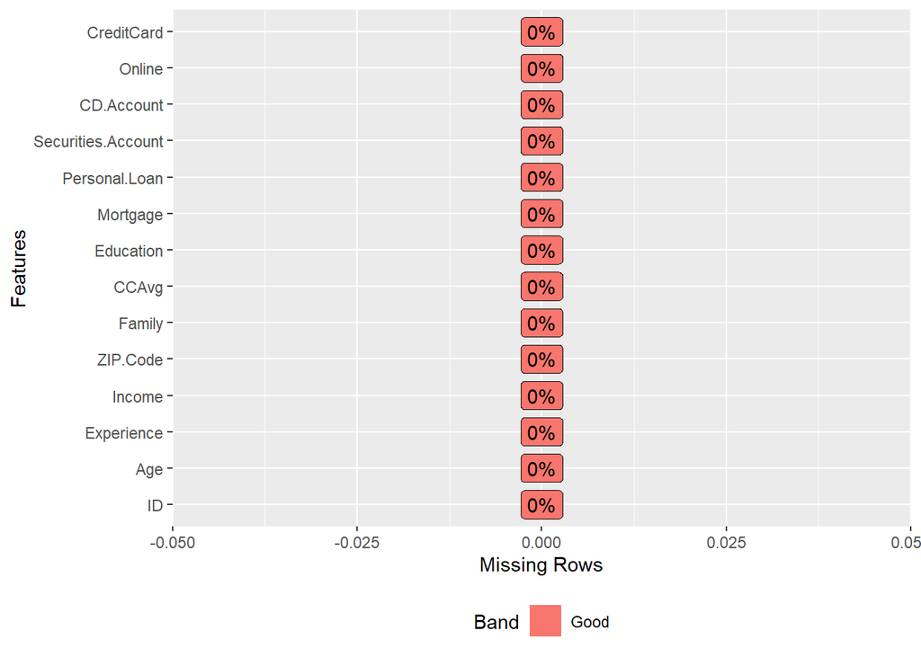

```r
plot_missing(UniBank) # Plots the percentages of missing values
```

```r
# Create a summary statistics table to show metrics, ensuring that missing values are not included
CSUM <- data.frame(mean = sapply(UniBank[,c(2:4, 6:14)], mean,na.rm = T)
                ,median = sapply(UniBank[,c(2:4, 6:14)], median,na.rm = T)
                ,min = sapply(UniBank[,c(2:4, 6:14)], min,na.rm = T)
                ,max = sapply(UniBank[,c(2:4, 6:14)], max,na.rm = T)
                ,sd = sapply(UniBank[,c(2:4, 6:14)], sd,na.rm = T))
colnames(CSUM) = c("Mean","Median","Min","Max","Standard Deviation")
CSUM
```

```
##                         Mean Median Min Max Standard Deviation
## Age                45.338400   45.0  23  67         11.4631656
## Experience         20.104600   20.0  -3  43         11.4679537
## Income             73.774200   64.0   8 224         46.0337293
## Family              2.396400    2.0   1   4          1.1476630
## CCAvg               1.937938    1.5   0  10          1.7476590
## Education           1.881000    2.0   1   3          0.8398691
## Mortgage           56.498800    0.0   0 635        101.7138021
## Personal.Loan       0.096000    0.0   0   1          0.2946207
## Securities.Account  0.104400    0.0   0   1          0.3058093
## CD.Account          0.060400    0.0   0   1          0.2382503
## Online              0.596800    1.0   0   1          0.4905893
## CreditCard          0.294000    0.0   0   1          0.4556375
```

```r
UniBank %>% gather() %>% head() # Reshaping the data which means it collects a set of column names and places them into a single “key” column
```

```
##   key value
## 1  ID     1
## 2  ID     2
## 3  ID     3
## 4  ID     4
## 5  ID     5
## 6  ID     6
```

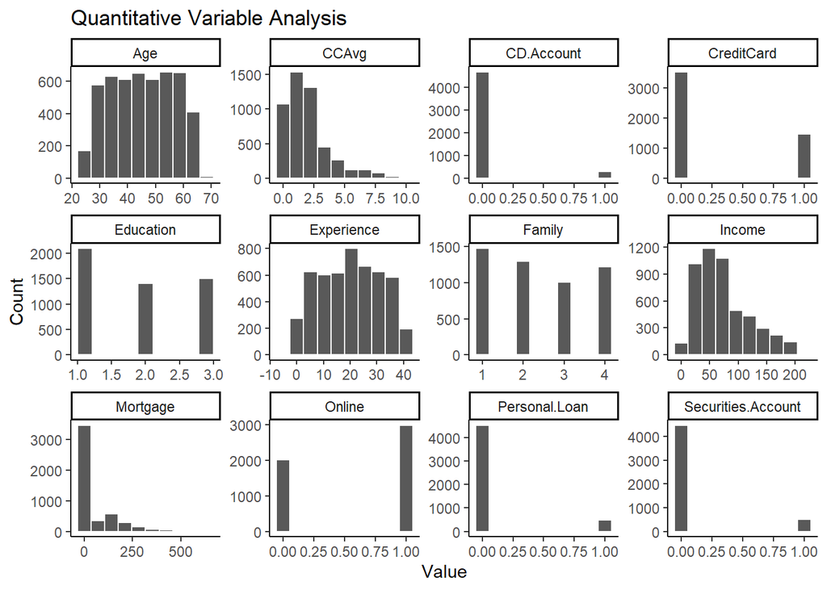

```r
UniBank_data <- UniBank[,-c(1,5)] # Remove ID and Zip from data to review quantitative values

ggplot(gather(data = UniBank_data),aes(value)) +
  geom_histogram(bins = 10, color = "white") + # Creates bin sizing and sets the lines as white
  facet_wrap(~key,scales = "free") + # Converting the graphs into panels
  ggtitle("Quantitative Variable Analysis") + # Title name
  ylab("Count") + xlab("Value") + # Label names
  theme_classic() # A classic theme, with x and y axis lines and no grid lines
```

# 7.2 Exercise - Personal Loan Acceptance

Universal Bank is a relatively young bank growing rapidly in terms of overall customer acquisition. The majority of these customers are liability customers (depositors) with varying sizes of relationship with the bank. The customer base of asset customers (borrowers) is quite small, and the bank is interested in expanding this base rapidly to bring in more loan business. In particular, it wants to explore ways of converting its liability customers to personal loan customers (while retaining them as depositors). A campaign that the bank ran last year for liability customers showed a healthy conversion rate of over 9% success. This has encouraged the retail marketing department to devise smarter campaigns with better target marketing. The goal is to use k-NN to predict whether a new customer will accept a loan offer. This will serve as the basis for the design of a new campaign.  
The file UniversalBank.csv contains data on 5000 customers. The data include customer demographic information (age, income, etc.), the customer’s relationship with the bank (mortgage, securities account, etc.), and the customer response to the last personal loan campaign (Personal Loan). Among these 5000 customers, only 480 (= 9.6%) accepted the personal loan that was offered to them in the earlier campaign. Partition the data into training (60%) and validation (40%) sets.

**A.** *Create a pivot table for the training data with Online as a column variable, CC as a row variable, and Loan as a secondary row variable. The values inside the table should convey the count. In R use functions melt() and cast(), or function table().*

```r
# Treat variables as categorical (R will create dummy variables) (page 245)
UniBank$Personal.Loan = as.factor(UniBank$Personal.Loan)
UniBank$Online = as.factor(UniBank$Online)
UniBank$CreditCard = as.factor(UniBank$CreditCard)

# Renamed the variables to show labels in pivot table
levels(UniBank$Personal.Loan) <- c("Loan Rejected", "Loan Accepted")
levels(UniBank$Online) <- c("Offline", "Online")
levels(UniBank$CreditCard) <- c("No Credit Card", "Credit Card")

str(UniBank)
```

```
## 'data.frame':    5000 obs. of  14 variables:
##  $ ID                : int  1 2 3 4 5 6 7 8 9 10 ...
##  $ Age               : int  25 45 39 35 35 37 53 50 35 34 ...
##  $ Experience        : int  1 19 15 9 8 13 27 24 10 9 ...
##  $ Income            : int  49 34 11 100 45 29 72 22 81 180 ...
##  $ ZIP.Code          : int  91107 90089 94720 94112 91330 92121 91711 93943 90089 93023 ...
##  $ Family            : int  4 3 1 1 4 4 2 1 3 1 ...
##  $ CCAvg             : num  1.6 1.5 1 2.7 1 0.4 1.5 0.3 0.6 8.9 ...
##  $ Education         : int  1 1 1 2 2 2 2 3 2 3 ...
##  $ Mortgage          : int  0 0 0 0 0 155 0 0 104 0 ...
##  $ Personal.Loan     : Factor w/ 2 levels "Loan Rejected",..: 1 1 1 1 1 1 1 1 1 2 ...
##  $ Securities.Account: int  1 1 0 0 0 0 0 0 0 0 ...
##  $ CD.Account        : int  0 0 0 0 0 0 0 0 0 0 ...
##  $ Online            : Factor w/ 2 levels "Offline","Online": 1 1 1 1 1 2 2 1 2 1 ...
##  $ CreditCard        : Factor w/ 2 levels "No Credit Card",..: 1 1 1 1 2 1 1 2 1 1 ...
```

```r
set.seed(111) #  Set the seed for the random number generator for reproducing the partition. (page 258)

# Partitioning into training (60%) and validation (40%) (page 38)
train.index <- sample(rownames(UniBank), 0.6*dim(UniBank)[1])
train.df <- UniBank[train.index, ] # Collect all the columns with training rows into training set (page 38)

valid.index <- setdiff(row.names(UniBank), train.index) # # Assign rows that are not already in the training set into validation (page 38)
valid.df <- UniBank[valid.index, ] # Collect all the columns with validation rows into validation set (page 38)
```

```r
# Creates a flat contingency table based on the exercises recommendation
pivot = ftable(train.df$CreditCard, train.df$Personal.Loan, train.df$Online)
pivot
```

```
##                               Offline Online
##
## No Credit Card Loan Rejected      797   1099
##                Loan Accepted       79    126
## Credit Card    Loan Rejected      315    497
##                Loan Accepted       33     54
```

In this first analysis, there are three key features in review:  
1. Do customers have credit card issued by the bank?  
2. Did customers open a personal loan that was offered at the last campaign?  
3. Do customers utilize Universal’s online services?

It was pointed out earlier that customers seemed to have a larger online presence compared to the other accounts. This can be confirmed within the pivot table as 1,776 customers are using the internet services. This percentage accounts for those who do and do not have a personal loan or credit card. Since a majority of individuals do not have a personal loan or credit card, we can assume they are on the bank’s website or application for other reasons. Additionally, there are only 9.73% out of the 3,000 customers who have a personal loan, and 29.97% who have a credit card regardless if they have a loan or an online presence. These breakdowns will play an important role later as we isolate our data to see how these attributes will classify individuals.

**B.** *Consider the task of classifying a customer who owns a bank credit card and is actively using online banking services. Looking at the pivot table, what is the probability that this customer will accept the loan offer? [This is the probability of loan acceptance (Loan = 1) conditional on having a bank credit card (CC = 1) and being an active user of online banking services (Online = 1)].*

```r
# Using the value positions within the pivot table to calculate Bayes (page 190 formula)

Bayes = pivot[4,2]/(pivot[3,2] + pivot[4,2])
paste(format(round(100*Bayes,2), nsmall = 2), "%") # Formatting the value
```

```
## [1] "9.80 %"
```

The chance that a customer who owns a credit card and is actively using the online services is pretty low. The probability that the bank can expect a customer to accept a loan is 9.80%.

**C.** *Create two separate pivot tables for the training data. One will have Loan (rows) as a function of Online (columns) and the other will have Loan (rows) as a function of CC.*

```r
# Creates a flat contingency table based on the exercises recommendation
pivot_online = ftable(train.df$Personal.Loan, train.df$Online)
pivot_online
```

```
##                Offline Online
##
## Loan Rejected     1112   1596
## Loan Accepted      112    180
```

```r
pivot_cc = ftable(train.df$Personal.Loan, train.df$CreditCard)
pivot_cc
```

```
##                No Credit Card Credit Card
##
## Loan Rejected            1896         812
## Loan Accepted             205          87
```

The pivot table is a broken out into Online and Credit Cards, kind of like what we see in **A**. Here, we can break out loan as a function of online and creditcard. This is helpful because we can confirm that most of our customers (90.26%) do not have a loan, 40.8% are not utilizing the online services, and 70.03% do not have a credit card. These values demonstrate that Universal could have the opportunity to market certain services or accounts to their customers which could increase sales.

**D.** *Compute the following quantities [P(A | B) means “the probability of A given B”]:*  
**i.** *P(CC = 1 | Loan = 1) (the proportion of credit card holders among the loan acceptors)*

```r
# Using the pivot value value positions to calculate the probabilities

i = pivot_cc[2,2]/(pivot_cc[2,1]+pivot_cc[2,2]) # [row, column] position
paste(format(round(100*i,2), nsmall = 2), "%") # Formatting the value
```

```
## [1] "29.79 %"
```

The probability that a customer has a credit card given a personal loan is 29.79%.

**ii.** *P(Online = 1 | Loan = 1)*

```r
# Using the pivot value value positions to calculate the probabilities

ii = pivot_online[2,2]/(pivot_online[2,1]+pivot_online[2,2]) # [row, column] position
paste(format(round(100*ii,2), nsmall = 2), "%") # Formatting the value
```

```
## [1] "61.64 %"
```

The probability that a customer uses Universal’s online services given a personal loan is 61.64%.

**iii.** *P(Loan = 1) (the proportion of loan acceptors)*

```r
# Using the pivot value value positions to calculate the probabilities

iii = (pivot_online[2,1] + pivot_online[2,2])/sum(pivot_online) # [row, column] position
paste(format(round(100*iii,2), nsmall = 2), "%") # Formatting the value
```

```
## [1] "9.73 %"
```

The probability that a customer has personal loan is 9.73%.

**iv.** *P(CC = 1 | Loan = 0)*

```r
# Using the pivot value value positions to calculate the probabilities

iv = pivot_cc[1,2]/(pivot_cc[1,1]+pivot_cc[1,2]) # [row, column] position
paste(format(round(100*iv,2), nsmall = 2), "%") # Formatting the value
```

```
## [1] "29.99 %"
```

The probability that a customer has a credit card given they do not have a personal loan is 29.99%.

**v.** *P(Online = 1 | Loan = 0)*

```r
# Using the pivot value value positions to calculate the probabilities

v = pivot_online[1,2]/(pivot_online[1,1]+pivot_online[1,2]) # [row, column] position
paste(format(round(100*v,2), nsmall = 2), "%") # Formatting the value
```

```
## [1] "58.94 %"
```

The probability that a customer has a online presence given they do not have a personal loan is 58.94%.

**vi.** *P(Loan = 0)*

```r
# Using the pivot value value positions to calculate the probabilities

vi = (pivot_online[1,1] + pivot_online[1,2])/sum(pivot_online) # [row, column] position
paste(format(round(100*vi,2), nsmall = 2), "%") # Formatting the value
```

```
## [1] "90.27 %"
```

The probability that a customer does not have a personal loan is 90.27%.

**E.** *Use the quantities computed above to compute the naive Bayes probability P(Loan = 1 | CC = 1, Online = 1).*

```r
# Calculating Naive Bayes by output values in D (page 191 formula)
NaiveBayes <- (i*ii*iii)/(i*ii*iii+iv*v*vi)

N <- paste(round(100*NaiveBayes,2),"%")
N
```

```
## [1] "10.08 %"
```

**F.** *Compare this value with the one obtained from the pivot table in (b). Which is a more accurate estimate?*

```r
# Comparing Bayes and Naive Bayes by calling each variable

y = "Bayes:"
paste(y, round(100*Bayes,2),"%")
```

```
## [1] "Bayes: 9.8 %"
```

```r
x = "Naive Bayes:"
paste(x, round(100*NaiveBayes,2),"%")
```

```
## [1] "Naive Bayes: 10.08 %"
```

The two theorems produce similar results, but not quite. Naive Bayes (NB) assumes independence of the predictor variables and ignores prior distribution of parameters. In the real world, assuming independence is rare. Naive pays attention to complex interactions and local structure, as well as works best when the goal is to classify or rank. If the goal is to estimate actual probabilities (which are the exercises above), the results would be biased. Therefore, the better estimator would be Bayes at 9.80%.

**G.** *Which of the entries in this table are needed for computing P(Loan = 1 | CC = 1, Online = 1)? In R, run naive Bayes on the data. Examine the model output on training data, and find the entry that corresponds to P(Loan = 1 | CC = 1, Online = 1). Compare this to the number you obtained in (E).*

To calculate the Naive Bayes output, there are only two values that are needed within the pivot table below. They are at positions [4,2] and [3,2], which correlate to 54 and 497. To compare the output above in Naive Bayes and in **E** and here, we must utilize the naiveBayes() function which outputs essentially what we found in the pivot table but in percentages.

```r
pivot # Calling pivot table from A to show comparison
```

```
##                               Offline Online
##
## No Credit Card Loan Rejected      797   1099
##                Loan Accepted       79    126
## Credit Card    Loan Rejected      315    497
##                Loan Accepted       33     54
```

```r
# Applying Naive Bayes classifier
NaiveBayes2 = naiveBayes(Personal.Loan ~ Online + CreditCard, data = train.df)
NaiveBayes2
```

```
##
## Naive Bayes Classifier for Discrete Predictors
##
## Call:
## naiveBayes.default(x = X, y = Y, laplace = laplace)
##
## A-priori probabilities:
## Y
## Loan Rejected Loan Accepted
##    0.90266667    0.09733333
##
## Conditional probabilities:
##                Online
## Y                 Offline    Online
##   Loan Rejected 0.4106352 0.5893648
##   Loan Accepted 0.3835616 0.6164384
##
##                CreditCard
## Y               No Credit Card Credit Card
##   Loan Rejected      0.7001477   0.2998523
##   Loan Accepted      0.7020548   0.2979452
```

```r
# Calculate the value of each cell in a table as a proportion of all values
a_priori = prop.table(NaiveBayes2$apriori)
online = NaiveBayes2$tables$Online
credit = NaiveBayes2$tables$CreditCard

# Calculation of Naive Bayes - similar to exercises above
a = a_priori[1] * online[1,2] * credit[1,2]
b = a_priori[2] * online[2,2] * credit[2,2]

nbayes2 = 1/(1+(a/b))

z = "Naive Bayes Recalculated:"
paste(z, round(100*nbayes2,2),"%")
```

```
## [1] "Naive Bayes Recalculated: 10.08 %"
```

Within the Naive Bayes Classifier for Discrete Predictors table, there were several elements that were needed. They are the following:  
- The percentage of customers who **do not have** a personal loan (90.26%)  
- The percentage of customers who **do have** a personal loan (9.73%)  
- The percentage of customers who **do not have** a personal loan but **have** online services (58.94%)  
- The percentage of customers who **do not have** a personal loan and **do not have** online services (41.06%)  
- The percentage of customers who **do have** a personal loan but **have** online services (61.64%)  
- The percentage of customers who **do have** a personal loan but **do not have** online services (38.36%)  
- The percentage of customers who **do not have** a personal loan but **have** credit card (29.99%)  
- The percentage of customers who **do not have** a personal loan and **do not have** credit card (70.01%)  
- The percentage of customers who **do have** a personal loan but **have** credit card (29.79%)  
- The percentage of customers who **do have** a personal loan but **do not have** credit card (70.21%)

The value in **E** is equivalent to the recalculation of the Naive Bayes in **G**, as they both are 10.08%.